# TAE - Unit 7 - Recitation

GT

June 3, 2016

## The Good, the Bad and the Ugly

With great power comes great responsibility.

There are many ways to visualize the same data.

You have just seen how to make quite attractive visualizations with ggplot2, which has good default settings, but judgment is still required from the user. For example, do I decide to vary the size of a point or do I vary the color of a point?

It is worth noting at this point that Excel and other similar programs can also be used to make perfectly acceptable visualizations, or terrible ones. The tool can help, but it’s ultimately up to the user to make decisions.

So what is the difference between a good visualization and a bad visualization then?

- *Good visualization* **clearly and accurately conveys the key messages** in the data.
- *Bad visualization* **will obfuscate the data either through ignorance or malice**

So what does this mean?

Visualizations can be used by an analyst for their own consumption to gain insights into the data.

Visualizations can also be used to provide information to a decision maker and/or to convince someone of something.

Now, a bad visualization can hide patterns that could give insight or mislead decision makers. This is where the malice part comes in.

We will look at a few examples of visualizations taken from a variety of sources.

We’ll discuss what is good and what is bad about them.

Then we will switch into R to build better versions of them for ourselves.

But I want you to think for yourself in this recitation. You might not agree with all the points I make or my opinions about these visualizations.

Visualization is inherently subjective and the right visualization will depend on the situation. So use your own judgment and think about what I talked about before with a good visualization and a bad visualization.

### Pie Charts

There are a lot of visualizations in the world and we don’t have time for them all.

So let’s focus on one particularly abused plot type, *the pie chart*.

This data set contains information for all versions of Apple’s iOS, which is used in the iPhone, as well as the various versions of Google’s Android.

Putting aside, for a moment, that there are far too many labels, check out the ordering of the labels corresponding to iOS.

Two sensible ways of ordering iOS data might be by decreasing percentage or by version number.

Instead, we start at the top with iOS 3.13, with 0%, and then jump to iOS 4.2.10, with 12.64%, before going back down to iOS 3.2, with 0.00% again. Which brings us to the number of labels.

Many of the segments are so narrow that they can’t be seen, although technically, all data is retained, because every segment is labeled.

If we look at iOS, we see that there are only three major versions, 3, 4, and 5, suggesting we can compress down the iOS segments to just three segments, while retaining most of the information. At the least, the versions that differ in the third number should be combined, and all data points of 0% should be removed.

The more fundamental concern of this visualization is that it might really be showing the percentage of the phone market using each operating system, and says nothing about whether one operating system crashes more than the other, which is the focus of this visualization.

Firstly, the pie chart is, for some reason, plotted on a hemisphere, a graphical effect that adds nothing, but has the effect of vertically compressing the pie chart.

Next, there is the issue of label orientation. While the caption, “Shark species (total/deaths)”, and the label, “White shark”, are horizontal, the rest are vertical and hard to read. They are in order, however, which does help.

Although the “Others” segment is unfortunately large, which is unclear if it is due to there being a lot of attacks by many species, or if the species is not known for many attacks.

Finally, at a glance, it is hard to distinguish the magnitude of differences between the orange, green, blue, and brown segments in the top part of the pie chart, and we must resort to the labels to distinguish between them. There is no meaning in the colors, they are arbitrary.

First of all, not all of the segments are labeled, so that data is lost, for the Middle East, Africa, Oceania, and the unknown regions.

Second, again, we have colors that are arbitrary and almost close enough to be confusing. The difference between Asia and Africa’s colors is subtle.

And of course, the 3D-effect on the pie chart adds nothing, but does play a subtle trick on the eye. Due to the 3D-effect, the blue and red segments are actually larger looking, which at a glance, may lead the viewer to overestimate their size.

What we are going to do now is, switch over to R and plot this data more appropriately, using ggplot. And then we’ll return to the slides, to discuss some more possibilities for this data.

### Bar Charts in R

Okay, so now we’re going to start with a simple bar plot of the MIT international student data.

So first, let’s load the ggplot library, ggplot2, and load the data frame.

```r
library(ggplot2)
intl = read.csv("intl.csv")
str(intl)
```

```
## 'data.frame':    8 obs. of  2 variables:
##  $ Region       : Factor w/ 8 levels "Africa","Asia",..: 2 3 6 4 5 1 7 8
##  $ PercentOfIntl: num  0.531 0.201 0.098 0.09 0.054 0.02 0.015 0.002
```

The structure of this data frame is very simple. There are two columns, two variables. The first one, the region, and the second one is the percentage of international students who came from that region.

So making a bar plot from this data isn’t too hard. We start off with a ggplot command, of course, the first argument being the data frame. The aesthetic in this case is to have Region on the x-axis, and on the y-axis, to have the percentage of international students, the geometry we’re going to use is geom_bar. We want to label my bars with the value, so it’s easy to read in closer detail.

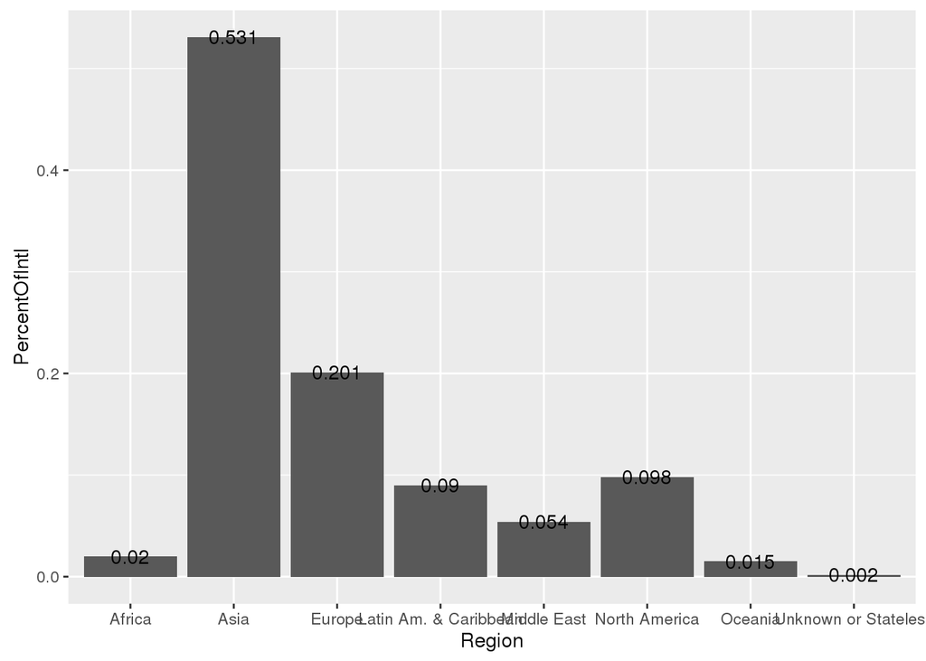

```r
ggplot(intl, aes(x=Region, y=PercentOfIntl)) + geom_bar(stat="identity") + geom_text(aes(label=PercentOfIntl))
```

So yes, we have a bar for each region. The values are between zero and one, which looks kind of strange. The labels are actually lying over the top of the columns, which isn’t very nice, and the regions aren’t really ordered in any way that’s useful. They’re actually ordered in alphabetical order, but I think it would be much more interesting to have them in descending order.

So we can work on this.

First of all, though, what is this stat = “identity”? Well, it’s pretty simple. Geometry bar has multiple modes of operation, and stat = “identity” says, use the value of the y variable as is, which is what we want. The height of the bar is the value of the y variable.

Now, there are other modes, including one that counts the number of rows for each value of x, and plots that instead.

But stat = “identity” is what we want right now. Now, the x-axis is out of order. And the reason for this is that ggplot defaults to alphabetical order for the x-axis.

What we need to do is make Region an ordered factor instead of an unordered factor.We can do this with the reorder command and the transform command. So let’s write this out.

```r
intl = transform(intl, Region = reorder(Region, -PercentOfIntl)) # reorder based on decreasing order of PercentOfIntl
str(intl)
```

```
## 'data.frame':    8 obs. of  2 variables:
##  $ Region       : Factor w/ 8 levels "Asia","Europe",..: 1 2 3 4 5 6 7 8
##   ..- attr(*, "scores")= num [1:8(1d)] -0.02 -0.531 -0.201 -0.09 -0.054 -0.098 -0.015 -0.002
##   .. ..- attr(*, "dimnames")=List of 1
##   .. .. ..$ : chr  "Africa" "Asia" "Europe" "Latin Am. & Caribbean" ...
##  $ PercentOfIntl: num  0.531 0.201 0.098 0.09 0.054 0.02 0.015 0.002
```

We see there’s something going on in the Region column that wasn’t going before. And that’s that ordering. So you might have also noticed that I put a negative sign in front of PercentOfIntl. So that negative sign means decreasing order. If we had left that out, it would have actually ordered them in increasing order. So that’s one thing fixed.

Another thing we didn’t like was that the numbers were between zero and one, which looks a little bit messy.

So let’s just simply multiply all the values by 100.

```r
intl$PercentOfIntl = intl$PercentOfIntl*100
```

And now the other things we have to fix, like the text overlying and the x-axis being all bunched up like that, we’re going to do that in a new ggplot command.

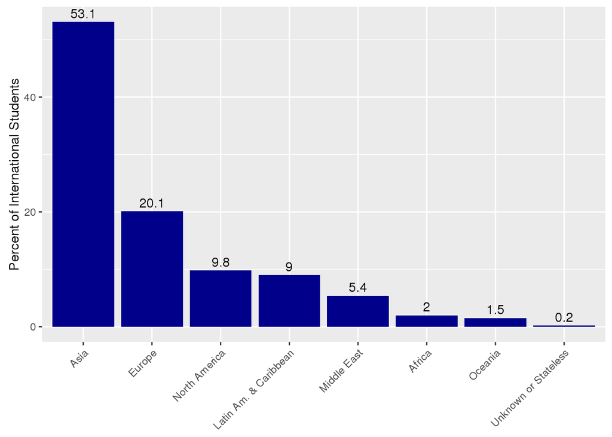

```r
ggplot(intl, aes(x=Region, y=PercentOfIntl)) +
  geom_bar(stat="identity", fill="dark blue") +
  geom_text(aes(label=PercentOfIntl), vjust = -0.4) + # it moves the labels up a little bit
  ylab("Percent of International Students") +
  theme(axis.title.x = element_blank(), axis.text.x = element_text(angle = 45, hjust = 1))
```

So we’ve got our labels vjust-ed above the columns. The bars themselves are dark blue. The numbers are now between 0 and 100, instead of zero and one. We can read all the text labels. And it’s generally a lot more readable than the pie plot or our original ggplot, at that.

Let’s go back to the slides now and talk about what we’ve just done.

### A Better Visualization

When we compare it back to the pie graph, the first thing I notice is that now all the data is visible. We haven’t lost the small regions and we can read out the exact share that comes from Africa, Oceania, and the unknown or stateless column.

I believe it is also easier to compare the relative sizes of each region because they’re all put side by side on a similar scale. There’s no tricks, or three dimensions, or colors to create a perception issue.

But, I will say that something to consider is, for some people and some applications, being not as visually exciting is a negative.

This plot, while very readable and correct, is certainly a little bit dull. In some applications, this is an important consideration.

Now, wouldn’t it be interesting if we could plot this data on a world map?

It would be possible, but a bit tedious to create because we need to determine which country lies in which region. Shading all countries in a region of the same color might be misleading though.

For example, countries in Latin America will send students at different rates, naturally. But, if we color them all the same color, it kind of gives a false impression. As it turns out, we actually have access to per country data.

So we will plot that on a world map instead and see if it is an effective way of communicating where students come from to MIT.

### World Maps in R

So now we’re going to try plotting a world map with a new data set that has the number of international students from each country.

So first of all, we’re going to need to use the ggmap package, which you may need to install. And we’re going to load in the data set, which is called intlall.csv.

```r
library(ggmap)
intlall = read.csv("intlall.csv", stringsAsFactors = FALSE)
head(intlall)
```

```
##           Citizenship UG  G SpecialUG SpecialG ExhangeVisiting Total
## 1             Albania  3  1         0        0               0     4
## 2 Antigua and Barbuda NA NA        NA        1              NA     1
## 3           Argentina NA 19        NA       NA              NA    19
## 4             Armenia  3  2        NA       NA              NA     5
## 5           Australia  6 32        NA       NA               1    39
## 6             Austria NA 11        NA       NA               5    16
```

Let’s look at the first few rows of intlall. So you see that each row corresponds to a country. There’s a citizenship column that’s the country name, number of undergraduates, number of graduates, special undergraduates and graduates, exchange or visiting, and a total column.

Now there’s these NAs in here, but they’re not really NAs. They’re just 0’s. So what we’re going to do is say, all these NAs should be 0’s.

```r
intlall[is.na(intlall)] = 0
head(intlall)
```

```
##           Citizenship UG  G SpecialUG SpecialG ExhangeVisiting Total
## 1             Albania  3  1         0        0               0     4
## 2 Antigua and Barbuda  0  0         0        1               0     1
## 3           Argentina  0 19         0        0               0    19
## 4             Armenia  3  2         0        0               0     5
## 5           Australia  6 32         0        0               1    39
## 6             Austria  0 11         0        0               5    16
```

Right, so next step is to load the world map.

```r
world_map = map_data("world")
```

```
##
##  # maps v3.1: updated 'world': all lakes moved to separate new #
##  # 'lakes' database. Type '?world' or 'news(package="maps")'.  #
```

```r
str(world_map)
```

```
## 'data.frame':    99338 obs. of  6 variables:
##  $ long     : num  -69.9 -69.9 -69.9 -70 -70.1 ...
##  $ lat      : num  12.5 12.4 12.4 12.5 12.5 ...
##  $ group    : num  1 1 1 1 1 1 1 1 1 1 ...
##  $ order    : int  1 2 3 4 5 6 7 8 9 10 ...
##  $ region   : chr  "Aruba" "Aruba" "Aruba" "Aruba" ...
##  $ subregion: chr  NA NA NA NA ...
```

So let’s look at the structure of the world_map. So the first two columns are the longitude and latitude; third column is something called group, that’s actually a group for each country, using a different number for each country; order, we’ll get to that later; region is just the country name, and subregion is sometimes used for some countries to describe islands and other things like that.

So we want to shove the world_map data frame and the intlall data frame into one data frame, so we can use it for ggplot.

```r
world_map = merge(world_map, intlall, by.x="region", by.y="Citizenship")
str(world_map)
```

```
## 'data.frame':    63634 obs. of  12 variables:
##  $ region         : chr  "Albania" "Albania" "Albania" "Albania" ...
##  $ long           : num  20.5 20.4 19.5 20.5 20.4 ...
##  $ lat            : num  41.3 39.8 42.5 40.1 41.5 ...
##  $ group          : num  6 6 6 6 6 6 6 6 6 6 ...
##  $ order          : int  789 822 870 815 786 821 818 779 879 795 ...
##  $ subregion      : chr  NA NA NA NA ...
##  $ UG             : num  3 3 3 3 3 3 3 3 3 3 ...
##  $ G              : num  1 1 1 1 1 1 1 1 1 1 ...
##  $ SpecialUG      : num  0 0 0 0 0 0 0 0 0 0 ...
##  $ SpecialG       : num  0 0 0 0 0 0 0 0 0 0 ...
##  $ ExhangeVisiting: num  0 0 0 0 0 0 0 0 0 0 ...
##  $ Total          : int  4 4 4 4 4 4 4 4 4 4 ...
```

Looks good.

So to plot a map, we use the geom_polygon geometry.

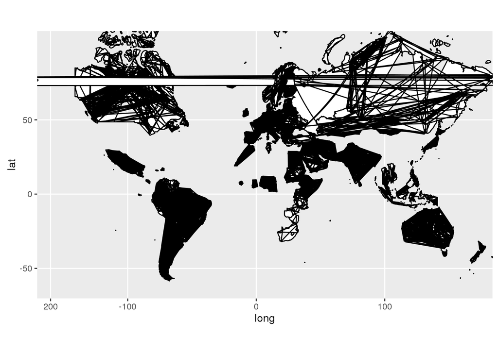

```r
ggplot(world_map, aes(x = long, y = lat, group = group)) +
  geom_polygon(fill="white", color="black") +
  coord_map("mercator")
```

So that looks kind of like a world map. There’s a few things going on here. So first of all, all the countries look like big black blobs. What on earth is going on, you might say.

Well, sometimes the merge can reorder the data. And it turns out that what the world_map data frame really is is actually a list of latitude and longitude points that define the border of each country. So if we accidentally reorder the data frame they no longer make any sense.

And as it goes from point to point, the points might be on the other side of the country as it defines the polygon.

So, we have to reorder the data in the correct order. So this command is a little bit complicated looking, but when you break it down, it’s not so bad. So, we take the world_map, and we’re going to reorder it.

So world_map, we’re going to reorder the rows. First of all, the group, which is pretty much equivalent to the country, and then the order variable, which is just the correct order for the border points. And we’re going to take all the columns, of course.

```r
world_map = world_map[order(world_map$group, world_map$order),]
```

Done. So if we go and try plotting it again

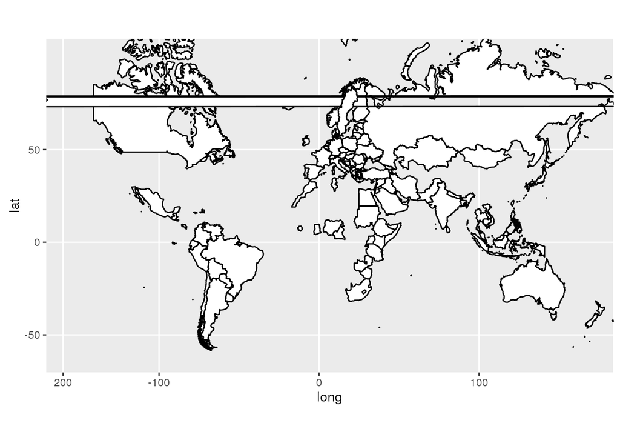

```r
ggplot(world_map, aes(x = long, y = lat, group = group)) +
  geom_polygon(fill="white", color="black") +
  coord_map("mercator")
```

There we go, much easier. Right, so now we have the map, and it looks far more reasonable. OK, next problem. Some of the countries are missing. Now of course, the USA is missing because MIT is in the USA, so that wouldn’t be an international student coming from the USA.

So, what do we do about that?

The reason China is missing is that it has a different name in the MIT data frame than in the world_map data frame. So when we merged them, it was dropped from the data set because it didn’t match up.

So to see what it’s called in the MIT data frame, let’s just do a table.

```r
table(intlall$Citizenship)
```

```
##
##                      Albania          Antigua and Barbuda
##                            1                            1
##                    Argentina                      Armenia
##                            1                            1
##                    Australia                      Austria
##                            1                            1
##                      Bahrain                   Bangladesh
##                            1                            1
##                      Belarus                      Belgium
##                            1                            1
##                      Bolivia           Bosnia-Hercegovina
##                            1                            1
##                       Brazil                     Bulgaria
##                            1                            1
##                     Cambodia                     Cameroon
##                            1                            1
##                       Canada                        Chile
##                            1                            1
## China (People's Republic Of)                     Colombia
##                            1                            1
##                   Costa Rica                Cote d'Ivoire
##                            1                            1
##                      Croatia                       Cyprus
##                            1                            1
##               Czech Republic                      Denmark
##                            1                            1
##                      Ecuador                        Egypt
##                            1                            1
##                  El Salvador                      Estonia
##                            1                            1
##                     Ethiopia                      Finland
##                            1                            1
##                       France                      Georgia
##                            1                            1
##                      Germany                        Ghana
##                            1                            1
##                       Greece                    Guatemala
##                            1                            1
##                        Haiti                    Hong Kong
```

[output cut: 60 more lines]

```
##                            1                            1
##            Trinidad & Tobago                      Tunisia
##                            1                            1
##                       Turkey                       Uganda
##                            1                            1
##                      Ukraine         United Arab Emirates
##                            1                            1
##               United Kingdom                      Unknown
##                            1                            1
##                      Uruguay                    Venezuela
##                            1                            1
##                      Vietnam                    West Bank
##                            1                            1
##                       Zambia                     Zimbabwe
##                            1                            1
```

If we scroll all the way up, we’ll see it says “China (People’s Republic Of)”. Now, in the world_map data frame, it’s simply called “China”.

So, what we can do is change the MIT data frame. So let’s say the citizenship column, the one row where it equals “China (People’s Republic Of)” should just be “China”.

```r
intlall$Citizenship[intlall$Citizenship=="China (People's Republic Of)"] = "China"
table(intlall$Citizenship)
```

```
##
##                      Albania          Antigua and Barbuda
##                            1                            1
##                    Argentina                      Armenia
##                            1                            1
##                    Australia                      Austria
##                            1                            1
##                      Bahrain                   Bangladesh
##                            1                            1
##                      Belarus                      Belgium
##                            1                            1
##                      Bolivia           Bosnia-Hercegovina
##                            1                            1
##                       Brazil                     Bulgaria
##                            1                            1
##                     Cambodia                     Cameroon
##                            1                            1
##                       Canada                        Chile
##                            1                            1
##                        China                     Colombia
##                            1                            1
##                   Costa Rica                Cote d'Ivoire
##                            1                            1
##                      Croatia                       Cyprus
##                            1                            1
##               Czech Republic                      Denmark
##                            1                            1
##                      Ecuador                        Egypt
##                            1                            1
##                  El Salvador                      Estonia
##                            1                            1
##                     Ethiopia                      Finland
##                            1                            1
##                       France                      Georgia
##                            1                            1
##                      Germany                        Ghana
##                            1                            1
##                       Greece                    Guatemala
##                            1                            1
##                        Haiti                    Hong Kong
```

[output cut: 60 more lines]

```
##                            1                            1
##            Trinidad & Tobago                      Tunisia
##                            1                            1
##                       Turkey                       Uganda
##                            1                            1
##                      Ukraine         United Arab Emirates
##                            1                            1
##               United Kingdom                      Unknown
##                            1                            1
##                      Uruguay                    Venezuela
##                            1                            1
##                      Vietnam                    West Bank
##                            1                            1
##                       Zambia                     Zimbabwe
##                            1                            1
```

OK, let’s check. Do the table again. Scroll all the way up. There it is, China. So we’ve fixed that.

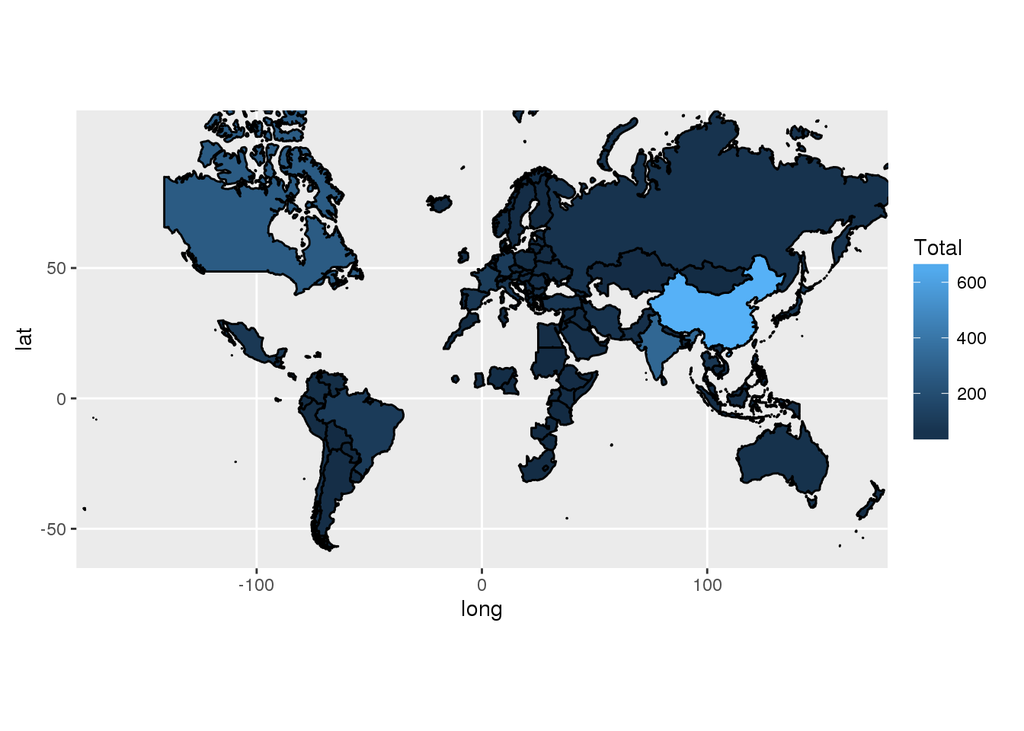

```r
world_map = merge(map_data("world"), intlall, by.x="region", by.y="Citizenship")
world_map = world_map[order(world_map$group, world_map$order),]
ggplot(world_map, aes(x = long, y = lat, group = group)) +
  geom_polygon(aes(fill=Total), color="black") +
  coord_map("mercator",xlim=c(-180,180), ylim=c(-60, 90)) # the limit fix the horizontal band
```

This is pretty interesting actually. So we can see that Canada, and China, and India supply a large number of international students to MIT. But it is a little bit confusing doing it on a per country basis, because Europe, presumably, has quite a few students at MIT.

But because Europe is made up of many small countries, it doesn’t look very impressive. Maybe if all the European countries were grouped together, it would look about the same color as Canada.

But it’s hard to tell. There are also other projections we can look at.

What I want to show you is an orthographic projection that allows you to sort of view the map in 3D, like a globe.

So let’s try that out.

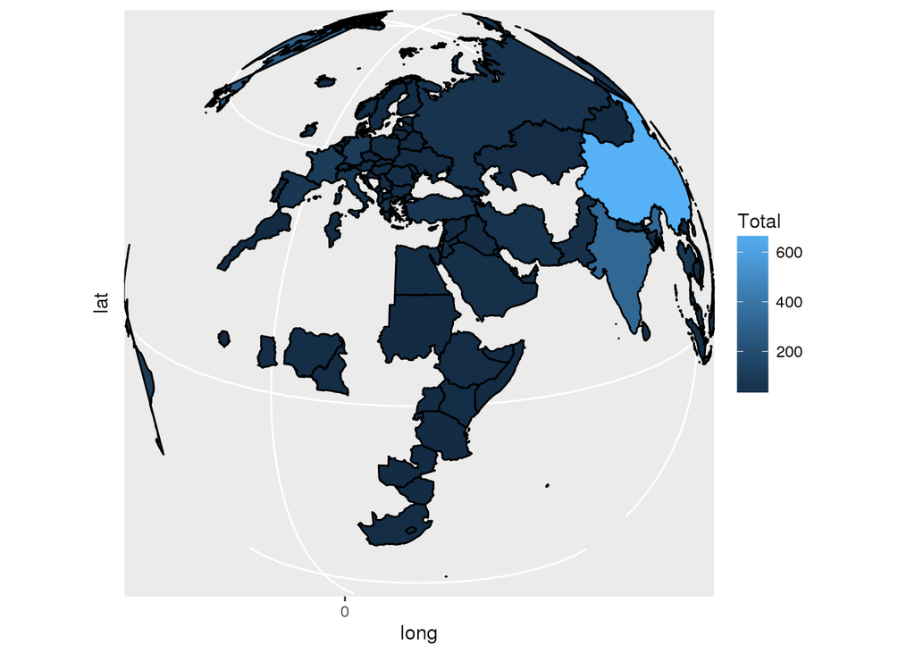

```r
ggplot(world_map, aes(x = long, y = lat, group = group)) +
  geom_polygon(aes(fill=Total), color="black") +
  coord_map("ortho",orientation = c(20, 30, 0),xlim=c(-180,180), ylim=c(-60, 90))
```

. If we run this, we should get a map centered above North Africa. That’s quite a nice visualization because if you want to look just at Africa and Europe, this is the way to go.

We can still see China, and Canada, and South America in there, as well.

Let’s do something a little bit more personal. I want to change the coordinates, now, to -37 and 175. Now it’s centered on my hometown of Auckland, New Zealand.

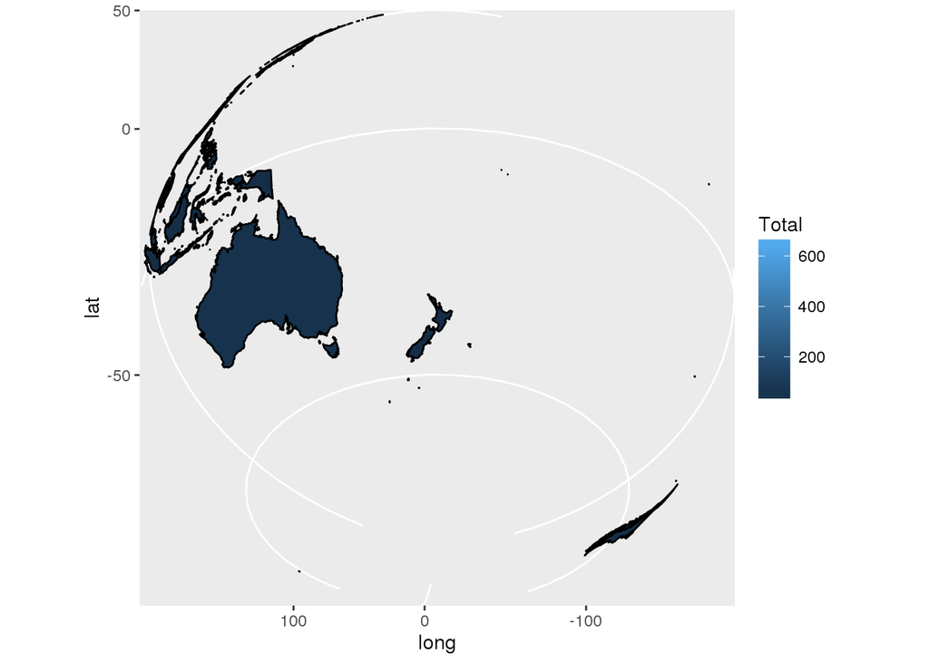

```r
ggplot(world_map, aes(x = long, y = lat, group = group)) +
  geom_polygon(aes(fill=Total), color="black") +
  coord_map("ortho",orientation = c(-37, 175, 0),xlim=c(-180,180), ylim=c(-60, 90))
```

### Scale

The real problem is the bars. If it was accurate, we would only really see the heads of the men, but instead we see their whole bodies, making it seem as if people have not only doubled in height, but they’ve also double in width.

The total range of the plot is 8% to 10%, although all the numbers fall in the range of 8.6% to 9.2%.

If we plotted the y-axis on a 0% to 10% scale, the conclusion would be that nothing is really changing at all.

The last point in the chart is at the wrong height, and the size of the markers makes the relative locations hard to distinguish.

Also notice that the gap between 9.0% and the 8.9% markers on the far left side, and the 8.9% and 8.8% markers, have a different gap.

A much bigger problem is that the scale of each blue bar is entirely different.

For example, the Native American bar is about a third of the length of the African American bar, but there are more than 10 times as many African Americans in this program as Native Americans.

In fact, visually, this plot is completely meaningless. The only useful thing about it is the numbers. But even there, there is a bit of confusion, as Native Americans are given to one decimal place, but the others are rounded.

Which when combined with the confusing scales, casts doubt on the correctness of the numbers.

On the left, we see the US military expense in the right axis, and troop count on the left axis. Both the line and bar plots are individually OK, but the combination is misleading.

Because you have mixed two units, dollars and people, there is a false impression of some sort of crossover point in 1995 that does not exist.

On the right is the same data presented in a different way.

We now have troops on the x-axis, and dollars on the y-axis. The line moves through time now, allowing us to see when moments of change occurred, such as decreases in troop count, through the 90s, at the end of the Cold War, the increase in spending of the 2000s, and the recent decreases in military spending.

The US Census Bureau periodically determines how many households are comprised, for example, of married couples with and without children, people living alone, and so on.

First of all, I’m not saying this is a bad visualization. In fact, if we are interested in the relative share of each type of household in a particular year, it’s actually pretty good.

However, if what we’re interested in is the rates of change across the years, this is next to useless.

The key problem is that the x-axis is completely off. The gap between the first two columns is 10 years, but the gap between the last two columns is only 2 years, meaning that the rates are hard to read from this.

If we’re not interested in the rates of changes, but just want to compare two years at a time, it’s not bad, but it’s not easy either.

Try comparing 1970 married without children to 2010 married without children, without looking at the numbers. Can you tell if it has grown or shrunk?

Finally, and more generally, this chart shows relative numbers. If you look at absolute numbers, we might find the total number of couples married with children is actually constant, but the number of other households has increased.

We are now going to change into R to try plotting this data as a line chart.

### Using Line Charts Instead

Now let’s load our data frame, which is in households.csv.

```r
households = read.csv("households.csv")
str(households)
```

```
## 'data.frame':    8 obs. of  7 variables:
##  $ Year          : int  1970 1980 1990 1995 2000 2005 2010 2012
##  $ MarriedWChild : num  40.3 30.9 26.3 25.5 24.1 22.9 20.9 19.6
##  $ MarriedWOChild: num  30.3 29.9 29.8 28.9 28.7 28.3 28.8 29.1
##  $ OtherFamily   : num  10.6 12.9 14.8 15.6 16 16.7 17.4 17.8
##  $ MenAlone      : num  5.6 8.6 9.7 10.2 10.7 11.3 11.9 12.3
##  $ WomenAlone    : num  11.5 14 14.9 14.7 14.8 15.3 14.8 15.2
##  $ OtherNonfamily: num  1.7 3.6 4.6 5 5.7 5.6 6.2 6.1
```

If we look at the structure of households, we see that there is a year column and then six other columns for each of the different household types.

So this is actually a problem for us. Given this structure of a data frame, what would we put in the aesthetic for our ggplot command?

It’s not obvious, to me at least, and in fact, I don’t think it’s really possible.

The reason is that ggplot needs it in the form of: year, group, and fraction.

The solution is to use the `melt` function from the reshape package.

Melt will take a 2-dimensional data frame like ours, and convert it into exactly the right form we need for ggplot2.

```r
library(reshape2)
```

Now, let’s look at the first two columns of our households data frame

```r
households[,1:2]
```

```
##   Year MarriedWChild
## 1 1970          40.3
## 2 1980          30.9
## 3 1990          26.3
## 4 1995          25.5
## 5 2000          24.1
## 6 2005          22.9
## 7 2010          20.9
## 8 2012          19.6
```

So there’s a Year and a MarriedWChild for each year.

Now, let’s look at the first few rows of our melted households data frame.

```r
head(melt(households, id="Year"))
```

```
##   Year      variable value
## 1 1970 MarriedWChild  40.3
## 2 1980 MarriedWChild  30.9
## 3 1990 MarriedWChild  26.3
## 4 1995 MarriedWChild  25.5
## 5 2000 MarriedWChild  24.1
## 6 2005 MarriedWChild  22.9
```

So, basically, what’s happened is that each value of MarriedWChild has turned into its own row in the new data frame.

So every value in our data frame now corresponds to a new row in our melted data frame, which is exactly what we need for ggplot.

So let’s try plotting this melted data frame.

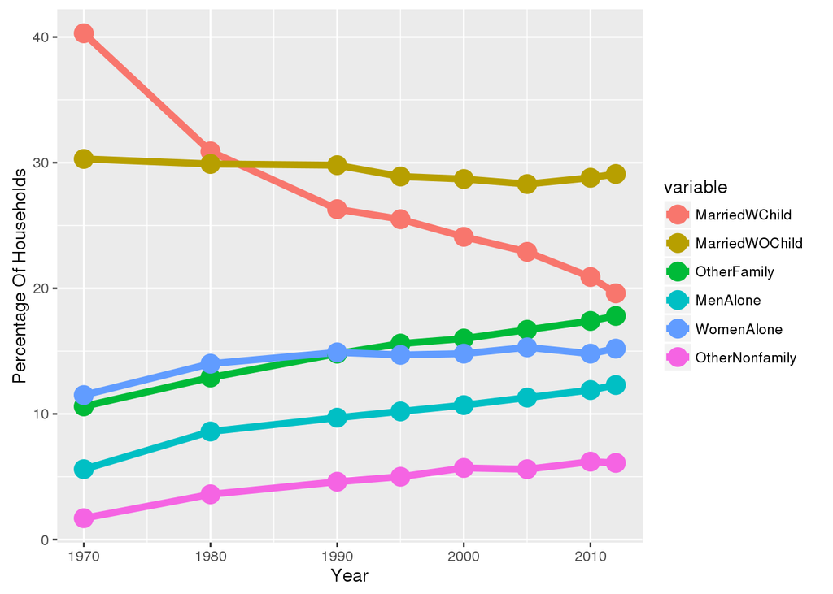

```r
ggplot(melt(households, id="Year"), aes(x = Year, y = value, color = variable)) +
  geom_line(size=2) +
  geom_point(size=5) +
  ylab("Percentage Of Households")
```

And there you go. Now, this is actually quite interesting when we compare it back to the chart we had in the slides.

Now you can see just how quickly MarriedWChild is decreasing as a relative share. You can also more clearly see that MarriedWOChild is pretty much flat, and that the differences being made up by the other four types of households is steadily increasing over the years.

So there you have it, the same data, plotted in two different ways. Now, I’m not saying one of these is better than the other one.

For example, if I want to compare inside a given year, say 1970, it’s not the most easy thing, at a glance, to see just how much of a total hundred percent is taken up by each.

But if I want to see across years, it’s far superior. And I can clearly see that the last data point is pretty much right next to the second to last data point, which is something that was hard to tell with the other visualization.

So I hope this has made you think a little bit more about the different ways you can plot the same data. And hopefully improved your ggplot2 skills a little bit more.